# Teoría del Interés I

## La Función de Acumulación

En un artículo anterior definimos el valor del dinero en el tiempo y vimos como se definia formalmente la tasa de interés $i$, ahora nos encargaremos de estudiar las ganancias generadas por dicha tasa de interés en el caso de que esta sea fija. Para ello, primero tomaremos el tiempo como una variable numérica $t$. Entonces, el *cómo* una inversión aumenta el capital invertido a través del tiempo será una función $a(t)$ con respecto al tiempo a la cual llamaremos **Función de Acumulación**, y debe de poseer dos cualidades básicas: $a(0) = 1$ y $a$ es creciente. Es decir, si un periodo de tiempo $t_1$ es menor que otro periodo $t_2$, entonces $a(t_1) \leq a(t_2)$. Así, para una inversión de capital $P > 0$, la función que determina el **Capital Total Resultante** $F(t)$ de la inversión tendrá la forma:

$$F(t) = P \cdot a(t)$$

En donde es y en la cual simplemente tomamos lo que invertimos y lo multiplicamos por la *forma* o *proporción* en la que va a aumentar. Un ejemplo de $a(t)$ es un porcentaje del $9\%$ mensual. Al invertir $100,000$ COP, acumularemos en un mes:

$$F(1) = P \cdot a(1) = 100,000 \cdot 1.09 = 109,000$$

Nótese que si el tiempo como variable no es **continuo**, entonces tomaremos como unidades los plazos establecidos para obtener el porcentaje de interés. Por ejemplo, si el interés del 9% se obtiene en un plazo trimestral, la unidad de tiempo $t = 1$ equivaldrá a tres meses, $t = 2$ equivaldría a seis meses, y así sucesivamente. Por lo tanto, el interés ganado en un periodo $n$-ésimo, es decir, $t = n$, es:

$$I_n = F(n) - F(n-1)$$

### Interés Efectivo

Si no conocemos el porcentaje o tasa de interés de una inversión, pero sí sabemos cuál es la función de acumulación $a(t)$, entonces podremos determinar primero el monto de dinero correspondiente a la unidad de tiempo por medio de la siguiente fórmula:

$$i = a(1) - a(0)$$

Si además quisiéramos saber la tasa de interés como un porcentaje, usamos en cambio esta otra (deducida de nuevo por la **medición del cambio relativo**):

$$i = \frac{a(1) - a(0)}{a(0)} = \frac{A(1) - A(0)}{A(0)} = \frac{I_1}{A(0)}.$$

## Interés Simple

El interés simple es aquel en el cual los intereses obtenidos en los periodos anteriores no afectan al actual ni a los futuros. Dicho de otra forma, la inversión siempre gana el mismo interés en cada periodo. Teniendo en cuenta que el tiempo$t$ se mide en dichos periodos, vamos a tener que en $t$ periodos tendremos la inversión inicial o *principal* llamado $P$ junto con el valor generado por la tasa de interés $i$ en los $t$ periodos con respecto a dicha inversión $P$. Por principio de suma y de multiplicación, esto sería lo mismo que decir:

$$F(t) = P+P\cdot i\cdot t = P \cdot (1 + it)$$

Donde $I$ es el capital total de la inversión más lo obtenido. Como ya se puede intuir (y como acabamos de ver), la función de acumulación de este tipo de interés es dicho factor:

$$a(t) = 1 + it.$$

## Interés Compuesto

El interés compuesto ocurre cuando, en vez de mantener un valor de inversión principal *constante*, vamos añadiendo el ingreso generado por el interés del periodo de tiempo inmediatamente anterior al periodo de inversión actual. Imaginemos dicha situación: realizamos la inversión de un principal $P$ que posee una tasa de interés $i$. En ese caso:

$$\begin{array}{|c|c|}
\hline
\textbf{Periodo de Tiempo }(t) & \textbf{Capital Total Final }(F) \\
\hline
t=1 & P+Pi=P(1+i) \\
\hline
t=2 & P+P(1+i)i=P(1+i)^2 \\
\hline
t=3 & P+P(1+i)^2i=P(1+i)^3 \\
\hline
... & ... \\
\hline
\end{array}$$

Y así sucesivamente, de manera tal que en un periodo de tiempo $t$ obtendremos el total de capital total resultante $F(t)$ como sigue:

$$F(t) = P(1 + i)^t$$

De donde se infiere que la función de acumulación $a(t)$ del interés compuesto es:

$$a(t) = (1 + i)^t.$$

### ¿Por qué elegir el Interés Compuesto?, Ejemplo 1:

Si en el caso de una inversión de interés constante tenemos la oportunidad de realizar un interés compuesto, esto es deseable en cualquier oportunidad. Aquí simplemente tomamos los rendimientos y los volvemos a invertir junto con el principal. Supongamos que decido invertir cien unidades monetarias $P = 100\ U$ a una tasa de interés trimestral fija de $i = 9\%$ durante un periodo de $30$ años, y debo elegir si realizar un interés simple $I_{S}$ o compuesto $I_{C}$. En ese caso, el capital final total de cada tipo de inversión será:

$$F_{S}(t) = 100 \left(1 + 0.09 \cdot \frac{30\cdot12}{3}\right) = 1,180\ U$$

$$F_{C}(t) = 100 \left(1 + 0.09\right)^{\frac{30\cdot12}{3}} \approx 3'098,701.57\ U$$

Como en cualquier otro caso, la inversión con interés compuesto (sin tomar en cuenta el riesgo, de ahí la tasa de interés fija) es mejor que el interés simple. Para dejarlo más claro, véase la gráfica que compara el *crecimiento* de la función de acumulación del interés simple vs. el compuesto:

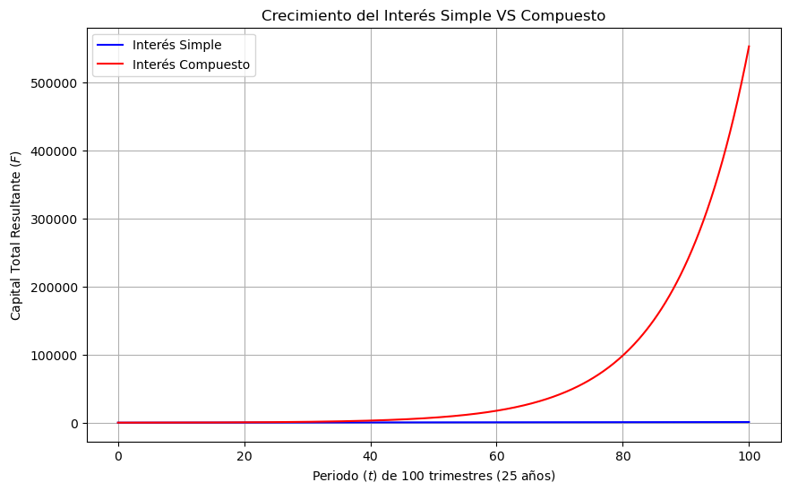

```python
import numpy as np
import matplotlib.pyplot as plt

# Definimos el intervalo [0, 100] para t
t = np.linspace(0, 100, 500)

# Definimos las funciones
a_S = 100 * (1 + 0.09 * t)
a_C = 100 * (1 + 0.09) ** t

# Graficamos las funciones
plt.figure(figsize=(10, 6))
plt.plot(t, a_S, label='Interés Simple', color='blue')
plt.plot(t, a_C, label='Interés Compuesto', color='red')

# Añadimos etiquetas y título
plt.xlabel(r'Periodo $(t)$ de $100$ trimestres (25 años)')
plt.ylabel(r'Capital Total Resultante $(F)$')
plt.title('Crecimiento del Interés Simple VS Compuesto')
plt.legend()
plt.grid(True)

# Mostramos el gráfico
plt.show()
```

## Valor Presente

El valor presente es la cantidad de dinero que debemos invertir hoy para obtener, en un tiempo dado, cierta cantidad de ganancias en el futuro. Es decir, es una función que, en base al capital final $F$ y al tiempo $t$, nos permite calcular el principal $P$. Podemos obtener esta función a partir de las fórmulas del interés que vimos anteriormente.

Para el **interés simple**, el valor presente se obtiene despejando la siguiente ecuación:

$$F=P(t)\cdot(1+it)\Rightarrow P(t)=\frac{F}{1+it}$$

El *factor* por el que se multiplica el valor final $F$ también puede entenderse (en general) como una función del tiempo denominada **Factor de Descuento** y se denota como $v(t)$. Es decir, en el caso del interés simple, el factor de descuento es:

$$v(t)=\frac{1}{1+it}.$$

Para el **interés compuesto**, también podemos determinar la fórmula del valor presente en función del capital final, obteniendo así el siguiente resultado:

$$F=P(t)\cdot(1+i)^t\Rightarrow P(t)=\frac{F}{(1+i)^t}$$

En este caso, el factor de descuento tiene la forma:

$$v(t)=\frac{1}{(1+i)^t}.$$

### Ejemplo de Valor Presente

Imaginemos una situación parecida a la anterior, es decir, una inversión con una tasa de interés trimestral fija de $i = 9\%$, y queremos saber ¿cuál es la cantidad inicial de dinero que debemos invertir para obtener una ganancia de $F = 10,000,000$ COP en un plazo de 5 años? Podemos realizar este ejercicio tanto con interés simple como compuesto. Cinco años equivalen a $20$ trimestres, de tal manera que $t = 20$, y los resultados serán:

- Para el interés simple:

$$P_{S}(20) = \frac{10,000,000}{1 + (0.09)(20)} \approx 3'571,428\ \text{COP}$$

- Para el interés compuesto:

$$P_{C}(20) = \frac{10,000,000}{(1 + 0.09)^{20}} \approx 1'784,309\ \text{COP}$$

## Referencias

- Huertas Campos, J. A. (2001). *Cálculo actuarial: Contingencias de vida individual*. Universidad Nacional de Colombia.
- Meza Orozco, Juan de Jesús (2011). *Matemáticas financieras aplicadas: Uso de las calculadoras financieras y Excel* (4ta Ed.). ECOE Ediciones.